# Climate Change Midpoint

Pranav Vasan, Arnav Gupta, Prerna Sheokand, Emily Giverts, Datta Dave

5/25/2020

## Introduction

Climate change has been a popular and important topic of discussion amongst people for several years now. Numerous scientists have gathered vast amounts of data to dicover trends in climate change over the decades. This project attempts to gather data from the last several centuries regarding fossil fuel carbon dioxide emission. This is very important, especially in the current day, because it will allow people to understand the effect of climate change and start taking preventive measures. Our [dataset](https://datahub.io/core/co2-fossil-by-nation) contains data from the Carbon Dioxide Information Analysis Center (CDIAC) for numerous countries from 1751 to 2014.

## Summary Information

Between 1751 and 2014, inclusive, UNITED STATES OF AMERICA was the nation that emitted the most fossil fuel carbon dioxide. Similarly, the year with highest amount of total emission was 2014. The dataset shows that QATAR had the most total emissions per capita and 2007 was the year with the most emissions per capita. The country that did best in terms of emitting the least fossil fuel carbon dioxide between these years was ANTARCTIC FISHERIES. Likewise, out of all of the years, 1751 was the year that had the least emissions among all of the countries combined.

## Chart 1

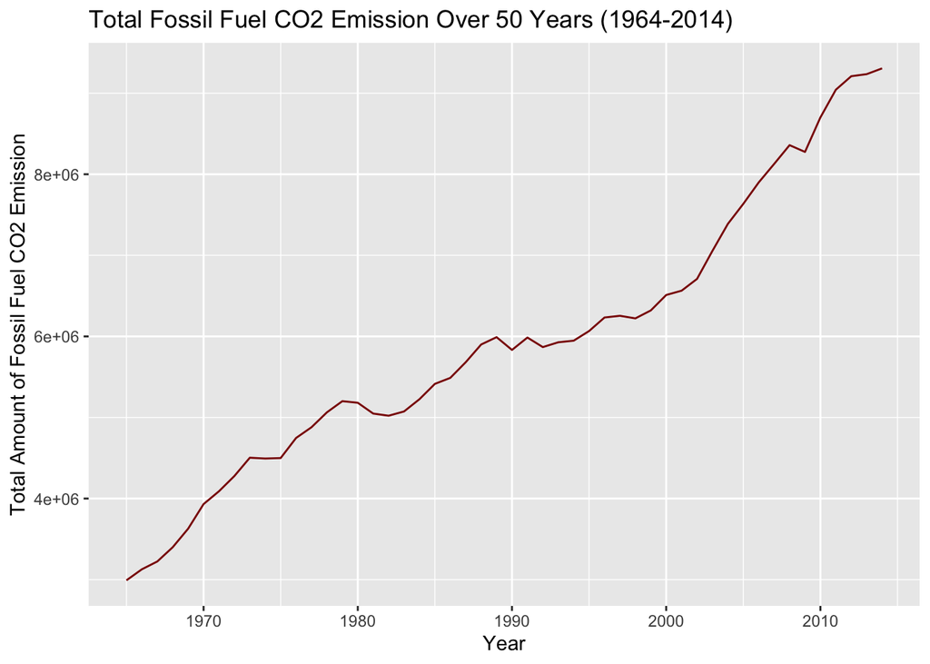

## Chart 2

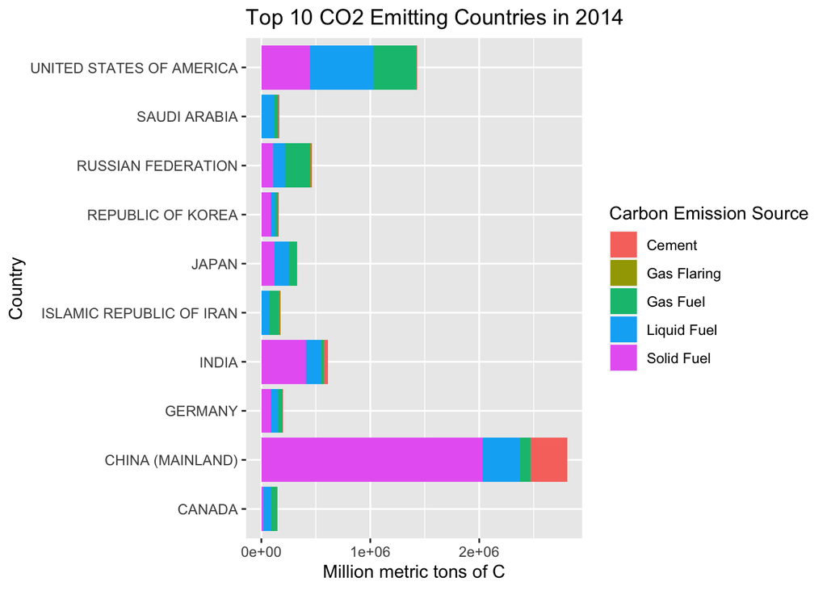

## Chart 3

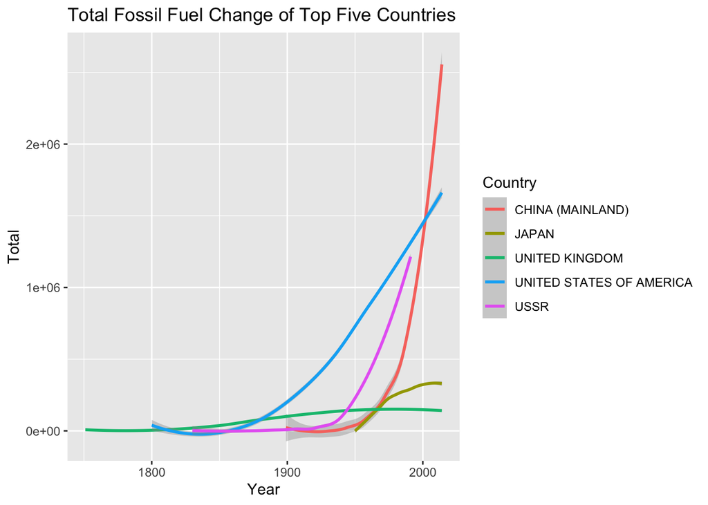

- One of the main goals for the exploration of this dataset was to observe change in fossil fuel contribution. This chart gathers information about the top five biggest contributors to fossil fuel emissions. This enables us to see similarities and differences between these nations as well as predict what could have contributed to changes in our data.
- Since this chart compares years to total emissions per country, we see how the United Kingdom had a steady head start compared to the other nations which can be attributed to the Industrial revolution. In the same sense, we can see how China started to contribute its own emissions much later on which we can predict to be a result of political and social change within the country.
- Japan’s fossil fuel emissions, although one of the greatest during the late 1900s, evens out in the early 2000s. This could be a result of heightened awareness of the environmental effects of fossil fuel emissions on the environment as well as increased regulations.